# The Effect of Police Layoffs on Crime: A Natural Experiment Involving New Jersey’s Two Largest Citie

Converted from PDF `Piza-PoliceLayoffsCrime-2021-JEJ.pdf` · 22 pages · anchors: page `#pN`, block `#pN-bK`

Page 1

[figure not shown]

NOTE: figure/graphic rendered as an image from the PDF; its content is not machine-readable text. Caption (if any) follows as the next block.

### **Justice Evaluation Journal**

#### **ISSN: (Print) (Online) Journal homepage: www.tandfonline.com/journals/rjej20**

## **The Effect of Police Layoffs on Crime: A Natural Experiment Involving New Jersey’s Two Largest Cities**

#### **Eric L. Piza & Vijay F. Chillar**

**To link to this article:** https://doi.org/10.1080/24751979.2020.1858697

Published online: 21 Dec 2020.

Full Terms & Conditions of access and use can be found at https://www.tandfonline.com/action/journalInformation?journalCode=rjej20

Page 2

### The Effect of Police Layoffs on Crime: A Natural Experiment Involving New Jersey’s Two Largest Cities

Eric L. Piza<sup>a</sup> and Vijay F. Chillar<sup>b</sup>

aJohn Jay College of Criminal Justice, Criminal Justice, New York, NY, USA; bSchool of Criminal Justice, Rutgers University Newark, Newark, NJ, USA

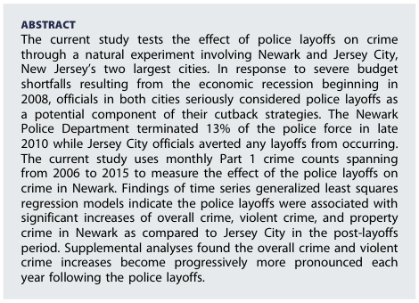

NOTE: figure/graphic rendered as an image from the PDF; its content is not machine-readable text. Caption (if any) follows as the next block.

**text found inside the figure**

ABSTRACT The current study tests the effect of police layoffs on crime through a natural experiment involving Newark and Jersey City, New Jersey’s two largest cities. In response to severe budget shortfalls resulting from the economic recession beginning in 2008, officials in both cities seriously considered police layoffs as a potential component of their cutback strategies. The Newark Police Department terminated 13% of the police force in late 2010 while Jersey City officials averted any layoffs from occurring. The current study uses monthly Part 1 crime counts spanning from 2006 to 2015 to measure the effect of the police layoffs on crime in Newark. Findings of time series generalized least squares regression models indicate the police layoffs were associated with significant increases of overall crime, violent crime, and property crime in Newark as compared to Jersey City in the post-layoffs period. Supplemental analyses found the overall crime and violent crime increases become progressively more pronounced each year following the police layoffs.

ARTICLE HISTORY Received 5 June 2020 Accepted 30 November 2020

KEYWORDS Police layoffs; police force size; natural experiment; police budgets; policing strategy

Introduction

In early 2008, the United States economy began a significant downturn, representing the 10<sup>th</sup> economic recession since World War II (Wiseman, 2011). Budget shortfalls required strategic cutbacks on the part of American police agencies over the approximately 18 months the recession lasted (COPS, 2011; Wiseman, 2011). An estimated 10,000 law enforcement jobs were lost during this time period (COPS, 2011). Researchers exploring the recession’s effect on policing have focused on issues such as the impact of officer layoffs on agency operations (COPS, 2011; PERF, 2010), cutback management strategies for police to consider (Wiseman, 2011), and the contextual factors associated with agencies either enacting or averting officer layoffs in the face of fiscal distress (Giblin & Nowacki, 2018). The effect of police officer layoffs on crime, to our knowledge, has yet to be subjected to empirical evaluation.

The literature on police force size provides a logical source for considering potential casual mechanisms linking police layoffs with changes in crime levels. Reviews of the

2020 Academy of Criminal Justice Sciences CONTACT Eric L. Piza epiza@jjay.cuny.edu

JUSTICE EVALUATION JOURNAL 2021, VOL. 4, NO. 2, 163–183 https://doi.org/10.1080/24751979.2020.1858697

Page 3

literature have generally found increasing police force size does not reduce crime (Lee, Eck, & Corsaro, 2016; Sherman & Eck, 2002) or improve organizational performance (Skogan & Frydl, 2004). However, negative relationships between police force size and crime have been observed in certain instances (Carriaga & Worrall, 2015). It is further important to note the majority of studies on police force size have tested small, gradual changes in officer levels. Research considering abrupt, drastic reductions in police force sizes (i.e., police strikes) has found officer reductions to be significantly related to crime increases (Sherman & Eck, 2002). While research suggests police strategy is a more important consideration for crime prevention than police force size (Lee et al., 2016), officer levels and changing strategy may not always be mutually exclusive. Sufficient manpower may be necessary to institute evidence-based crime prevention practices. At a time when police departments are at a cross-roads of potentially phasing out specialized units to meet budgetary constraints, this work adds to an ongoing contemporary debate about the impact of police force size on crime.

The current study seeks to contribute to the literature through a natural experiment testing the effect of police layoffs on crime. In 2008, the Newark Police Department (NPD) and Jersey City Police Department (JCPD), New Jersey’s two largest police forces, both seriously considered police layoffs due to severe budget cutbacks. The police union and city officials in Jersey City came to a contract agreement to avert officer layoffs (Porter, 2011). No such agreement occurred in Newark, leading to the termination of 13% of the NPD on November 30, 2010 (Star Ledger, 2010). Our analysis found that crime significantly increased in Newark as compared to Jersey City following the NPD layoffs. We conclude the paper with a discussion of the study implications for public policy, evidence-based policing, and contemporary policing research. We begin with a review of the relevant empirical literature.

Review of relevant literature

Research on the relationship between police force size and crime rate has spanned decades, methodologies, and statistical inquiry. Research has occurred often enough to allow for multiple systematic reviews of the literature over time. Eck and Maguire (2006) identified 27 studies containing 89 separate tests of police force size on crime. Only about 20% of the tests indicated a negative relationship, with 49% finding no effect and 30% finding a positive effect. Similar findings emerged when studies employing weak research designs (e.g., cross-sectional designs, unit of analysis larger than the city-level, and those failing to addresses simultaneity between police and crime) were excluded. Eck and Magurie (2006) concluded there was no consistent evidence that increasing police officer size impacts crime. Lim, Lee, and Cuvelier (2010) conducted a systematic review of 256 findings in 58 studies published between 1971 and 2009. They found most studies generated negative relationships between police force size and crime irrespective of their significance levels. While this would seemingly support the police force size hypothesis, Lim et al. (2010) determined that methodological limitations common in the original studies prevented any concrete conclusions from being reached.

164 E. L. PIZA AND V. F. CHILLAR

Page 4

Recent research has built upon the early systematic reviews by incorporating metaanalytic techniques to measure the overall effect of police force size on crime. Metaanalysis improves upon the “vote-counting” of individual study findings commonly employed in early systematic reviews. Meta-analysis combines disparate study findings into a single effect size reflecting the cumulative impact of the intervention under question (Lipsey & Wilson, 2001). Carriaga and Worrall (2015) identified 24 longitudinal studies measuring the effect of police levels on crime at a macro-level, with 12 studies providing the necessary data for inclusion in the meta-analysis. Findings of a votecounting procedure found mixed-evidence of police level effect on crime. However, the meta-analysis found the mean effect size of sworn officers on crime was small but statistically significant, indicative of a negative relationship between police levels and crime rates.

Lee et al. (2016) estimate a small, nonsignificant effect size suggesting police force size to be unrelated to crime. Lee et al. (2016) further contextualized their findings by comparing the police force effect size to those from meta-analyses of contemporary policing strategies: problem-oriented policing (Weisburd, Telep, Hinkle, & Eck, 2010), neighborhood watch (Bennett, Holloway, & Farrington, 2007), hot spots policing (Braga, Papachristos, & Hureau, 2014), and focused-deterrence (Braga & Weisburd, 2006). This exercise showed that the effect of police force size was, in the words of Lee et al. (2016), “miniscule” in comparison to these policing strategies. The cumulative findings of their study led Lee et al. (2016) to two main conclusions: (1) that research on the effect of police force size on crime has “exhausted its utility” and (2) changing policing strategy is likely to have a greater impact than adding more police.

Upon further inspection of the literature, the general lack of relationship between police force size and crime may be explained by how officers allocate their time on duty. Researchers have found the majority of police officer time constitutes activities unrelated to fighting crime (Black, 1971; Cumming, Cumming, & Edell, 1965; Payne, 2017). Perhaps we should not expect officer levels to significantly impact the crime rate given most incidents police respond to are not criminal in nature. However, research published since Carriaga and Worrall (2015) and Lee et al. (2016) suggests there may be a relationship when focusing on crime type, swiftness of force level change, and deployment strategy.

While the body of empirical research has found that adding police does not universally decrease crime, it does not mean that reducing the size of the police force will be without consequence in all instances (Payne, 2017). Recent studies by Chalfin and

JUSTICE EVALUATION JOURNAL 165

Page 5

McCrary (2018), Mello (2019), and Kaplan and Chalfin (2019) suggest the question researchers should be asking is whether police are impacting violent crime – particularly murder – and property crime in the same manner. Chalfin and McCrary (2018) incorporate various statistical models to account for simultaneity bias and suggest that police reduce murder to a greater extent than they do assault, larceny, and burglary. Similarly, Mello (2019) finds violent crime to be more responsive than property crime to increases in police force size. Specifically, one additional officer results in a decrease of 0.11 murders, 0.53 rapes, and 1.98 robberies. In a similar vein, Kaplan and Chalfin (2019) show the addition of one officer has the ability to prevent approximately seven index crimes – six property and one violent. A particularly noteworthy finding of the study is increasing the number of police does not lead to increased incarceration, representing what the authors call a “double dividend” – a decrease in crime and incarceration rates.

The aforementioned studies, including those used in the relevant meta-analyses, measured the effect of incremental force level changes on crime. The question then becomes what happens when change is drastic, and in the negative direction? The empirical literature on police strikes informs such research questions. Five of the six police strike studies reviewed by Sherman and Eck (2002) found major increases in both violent and property crime following police strikes (Andenaes, 1974; Clark, 1969; Makinen & Takala, 1980). The lone exception was the study by Pfuhl (1983), which found strikes across 11 cities had neither a statistically significant or systematic impact on rates of the reported crimes in question. However, Sherman and Eck (2002, p. 302) noted 89% of the “strike” period in Pfuhl’s study consisted of non-strike days, confounding the measurement of cause and effect. Nonetheless, we should note that the overall body of research on police strikes is methodologically weak with no study rating higher than 2 on the Maryland Scientific Methods Scale (Farrington, Gottfredson, Sherman, & Welsh, 2002; see Sherman & Eck, 2002, p. 303). As this is below the minimally interpretable research design (level 3) involving a comparable control condition it cannot be ruled out that crime would have increased in the absence of a strike.

When discussing the conflicting evidence in support of police force size as a crime control mechanism, it should be noted recent decades have seen the rise of evidencebased policing, which advocates for police strategy to be rooted in scientific evidence (Lum & Koper, 2017; Sherman, 1998). Generally speaking, proactive, focused, and place-based police interventions are more likely to result in reduced crime and disorder as compared to initiatives concentrating on individuals, or that that are reactive (Lum, Koper, & Telep, 2011; also see chapter 3 in Lum & Koper, 2017). The evidencebased policing literature supports Lee et al.’s (2016) conclusion that changing police strategy is likely to have a larger crime control effect than increasing the size of a police force.

An important caveat is effectively implementing evidence-based practices may require a department to employ a sufficient number of police officers. The Flint, MI police department (FPD) provides such an example, as the agency lost approximately 50% of its sworn officers (almost 300 to under 150 officers) over two decades (Terrill, Rossler, & Paoline Iii, 2014). This loss of officers prevented FPD from continuing its longstanding community policing initiatives or implementing contemporary strategies

166 E. L. PIZA AND V. F. CHILLAR

Page 6

such as hot spots policing, disorder reduction strategies, or CompStat due to a lack of resources, rather than resistance from police leadership or front-line personnel. Additionally, officers once assigned specifically to community policing were shifted to basic patrol following the budget cutbacks. A similar situation was observed in Newark, NJ, which directly informs the current study. In the summer of 2008, the NPD began Operation Impact, a foot-patrol saturation intervention that deployed 12 footpatrol officers in an approximately quarter-square mile area of the city on a nightly basis. An evaluation by Piza and O’Hara (2014) found the foot-patrols generated a significant reduction in overall violence as compared to two separate control areas (Piza & O’Hara, 2014). Despite the intervention proving beneficial, Operation Impact patrols were canceled and ultimately phased out due to budget shortfalls over the looming police layoffs (see Piza & O’Hara, 2014: 713).

Conversely, natural experiments levying current events have demonstrated the benefits of increasing police presence at a granular level. Di Tella and Schargrodsky (2004) and Draca, Machin, and Witt (2011) measured police increases in response to terrorist attacks in Buenos Aires and London, respectively, each finding evidence of crime decreases. Klick and Tabarrok (2005) used terror alert levels in Washington D.C. to demonstrate increased officer presence resulted in significant decreases of various crime types. Simpson and Hipp (2019) explored the bi-directional relationship between crime and increased levels of police stops and foot patrols. They found a significant negative relationship between police actions and crime, with city blocks experiencing more police stops having reduced odds of burglary in subsequent time periods.

The current study contributes to the literature through a natural experiment testing the effect of police layoffs on crime. Our methodology expands upon the prior literature primarily focused on incremental changes to police force size. The natural experiment involves New Jersey’s two largest cities, Newark and Jersey City. The Newark Police Department (NPD) terminated 13% of the police force on November 30, 2010 while Jersey City officials were able to avert layoffs. More detail on the negotiations preceding the officer layoffs and as well as the subsequent effect on agency practice appears below.

Methodology

Study setting

Newark and Jersey City are the two largest cities in New Jersey, with populations of 277,140 and 247,597, respectively, according to the 2010 decennial census. Ethnic minorities account for the majority of the citizenry, with only 12.2% of residents in Newark and 22.6% of residents in Jersey City identifying as White alone. In 2010, Newark and Jersey City boasted the two largest police forces in the state, employing 1,308 and 831 officers, respectively (FBI, 2011a). Both cities exhibited 2010 overall part 1-, violent-, and property-crime rates well above average for New Jersey municipalities with at least 50,000 residents (see Table 1). Nonetheless, as will be discussed subsequently, Newark and Jersey City experienced general reductions in crime during the preceding years. This is important in the context of the current study, as research suggests cities with diminishing crime rates may be more likely to consider police layoffs in the face of fiscal constraints (Giblin & Nowacki, 2018).

JUSTICE EVALUATION JOURNAL 167

Page 7

The loss of officers adversely impacted NPD practices. Following a change in leadership in 2006, the NPD committed to a placed-based approach to crime prevention. While the aforementioned Operation Impact program epitomized this strategy, all precincts regularly engaged in hot spots policing activities. The NPD frequently deployed teams of officers with little to no responsibility for responding to calls for service to maximize officer time in hot spots. These officers were primarily tasked with proactively policing Newark’s crime hot spots for the majority of their shifts. Taken as a whole, hot spots policing activities were a mainstay throughout Newark from 2006 through 2009. These practices were largely discontinued owing to the layoffs, as officers were needed for general patrol and response to citizen calls for service.

Evaluation design

The current study takes advantage of the unique timing of the fiscal crisis, budget negotiations, and police officer layoffs to conduct a natural experiment measuring the effect of police layoffs on crime in Newark. Natural experiments share certain characteristics with quasi-experiments, particularly that the creation of experimental and

Table 1. Study setting characteristics.

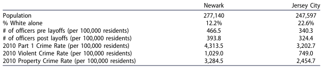

NOTE: complex table shown as an image of the PDF; the text below is a rough machine extraction and may be mis-aligned.

**extracted text (unreliable layout)**

Note: According to the 2010 UCR, the 32 New Jersey municipalities with 50,000 or more residents reported an average Part 1 crime rate of 2,763.8 per 100,000 residents, a violent crime rate of 479.0 per 100,0000 residents, and a property crime rate of 2,284.8 per 100,0000 residents.

168 E. L. PIZA AND V. F. CHILLAR

Page 8

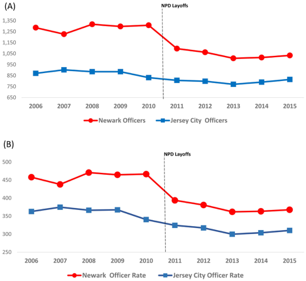

NOTE: figure/graphic rendered as an image from the PDF; its content is not machine-readable text. Caption (if any) follows as the next block.

control groups cannot be manipulated by researchers. However, quasi-experiments make no presumption that the allocation of the intervention occurred in any random fashion. This differs from natural experiments, in which the allocation of the experimental condition occurs in a random or as-if random process, despite falling outside the control of researchers (Dunning, 2008).

Demonstrating treatment occurred in a random or as-if random process is an important first step for any natural experiment. Without doing so, researchers risk “conceptual stretching” by applying the term “natural experiment” to studies with weaker designs (Dunning, 2012). We consider the situation observed with New Jersey’s two largest police departments as occurring in an as-if random process. We rely on the causal-process observation method, which Collier, Brady, and Seawright (2010: 184) describe as “an insight or piece of data that provides information about context, process, or mechanism.” Police unions and city administrators in both Newark and Jersey City actively negotiated to avoid police officer layoffs at the same point in

Figure 1. Number of police officers (A) and officers per 100,000 population (B) in Newark and Jersey City.

JUSTICE EVALUATION JOURNAL 169

Page 9

time, with neither the NPD or JCPD motivated to self-select into the experimental group experiencing layoffs.<sup>1</sup> Furthermore, as New Jersey’s two largest cities, Newark and Jersey City are more similar to one another than any of the other municipalities in the state in regards to police force size, pre-layoff police resources, and pre-layoff crime levels.

Analytical approach

Study period

The current study incorporates monthly crime data from 2006 through 2015 to reflect the local context in Newark. In 2006, Cory Booker began his first term as Newark Mayor, with crime control as his administration’s top priority. Booker installed a new Police Director at the NPD who stressed adherence to evidence-based practices, in particular proactive, place-based crime control strategies (Jenkins & DeCarlo, 2015). In January 2016, after Booker resigned as mayor following a successful campaign for the U.S. Senate, newly elected Mayor Ras Baraka merged Newark’s police department, fire department, and office of emergency management and homeland security into a single Department of Public Safety. While each entity maintained autonomy in determining strategy and daily operations, this merging of agencies allowed certain administrative tasks to be shared across the disparate public safety missions, freeing up more personnel to perform front-line duties. In recognition of these contextual factors, restricting the study period to 2006 through 2015 allows us to best isolate the effect of layoffs without the potentially confounding factors of a changing agency mission (pre-2006) or creation of the Department of Public Safety (post-2015).

Outcome measures

1We acknowledge the layoffs were technically the result of an explicit choice, specifically NPD’s union not accepting the new contract offer with JCPD’s union choosing the opposite. However, it is important to note police unions represent police officers, not bureaucratic police agencies. Police unions typically approach collective bargaining with the goal of preserving the labor interests of officers irrespective of the impact this has on police department operations (Decarlo & Jenkins, 2015). In the context of the police layoffs, an outside entity (i.e., police unions) decided upon a policy that directly impacted the research subjects (i.e., police departments) which we believe is distinct from self-selection. To illustrate this point, we draw a parallel to a natural experiment ranking high on Dunning’s (2008) “continuum of plausibility” regarding the as-if random standard: Snow’s ([1855] 1965) classic natural experiment of cholera transmission in London. Snow hypothesized cholera was a waterborne infectious disease spread via household water delivered by Lambeth Waterworks, one of London’s two water supply companies at the time. Snow noted the choice of water supply company was made by absentee landlords rather than the renters of the property. Therefore, renters transmitting cholera from the contaminated water of Lambeth Waterworks could not be considered as self-selecting into the experimental condition.

170 E. L. PIZA AND V. F. CHILLAR

Page 10

Independent variables

A binary measure identifies each observation as pertaining to Newark (“1”) or Jersey City (“0”). This variable was interacted with alternate measures of the post layoffperiod to calculate difference-in-differences (DiD) terms used as the primary independent variable. An important consideration is how the effect of police layoffs may manifest over time. As such, we computed two DiD terms for use in separate models to test the immediate effect and gradual effect of the police layoffs. For the immediate effect model, the DiD term interacts “Newark” with a binary measure reflecting the post-layoff period (December 2010 – December 2015) to measure how the termination of officers impacted crime levels during the full post-layoff time period. For the gradual effect model, the DiD term interacts “Newark” with a 5-scale ordinal measure representing each 12-month period following the layoffs (i.e., December 2010-November 2011 ¼ 1; December 2011 – November 2012 ¼ 2; and so on). This model measures how crime rates changed with each passing year following the layoffs.

Control variables

We sought to control for potential confounding factors by introducing additional variables in our statistical models. We consulted prior longitudinal policing studies in selecting control variables (e.g., Braga et al., 2010, 2011, 2011; Marvell & Moody, 1996; Piza & Gilchrist, 2018). The lagged outcome measure (t 1) controls for crime rates observed during the prior month. The number of days in the month controls for the potential exposure to crime, as longer months have more daily opportunities to experience crime. To control for the potential effect of seasonality on crime, we identified the quarter of the year each month fell within. The first quarter (January – March) was the reference category. A continuous variable measuring the sequential order of the monthly time periods (January 2006 ¼ 1; February 2006 ¼ 2; and so on) accounts for the linear trend in the data.<sup>3</sup>

2In consideration of the data sources and context of the study setting, both rape and arson were excluded from the analysis. The UCR definition of rape changed in 2013, negatively affecting this measure’s reliability over the study period. Arson is not actively collected by the New Jersey State Police, given the control of arson is typically considered the purview of fire departments and not the police. This is certainly the case in Newark, with the police department excluding arson from both its internal CompStat reports as well as their public crime statistics web page: see https://npd.newarkpublicsafety.org/comstat 3The reader may be concerned with whether changing sociodemographic conditions in Newark or Jersey City influenced crime rates. Given the relatively small number of observations in our database, we opted against including such controls in the main analysis to avoid potential model overfitting. However, we present results of models controlling for 9 sociodemographic variables in the appendix. These results do not meaningfully differ from the main analysis presented in-text.

JUSTICE EVALUATION JOURNAL 171

Page 11

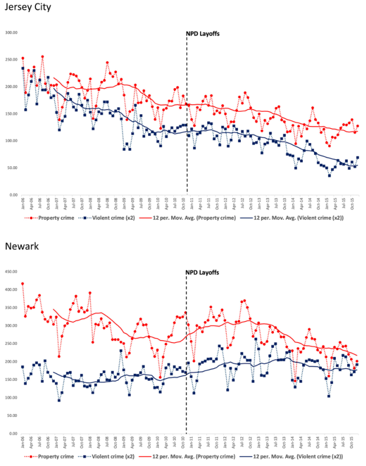

NOTE: figure/graphic rendered as an image from the PDF; its content is not machine-readable text. Caption (if any) follows as the next block.

Results

Figure 2. Violent crime and property crime rates (per 100,000 population).

172 E. L. PIZA AND V. F. CHILLAR

Page 12

Tables 2-4 display the results of the generalized linear regression models.<sup>4</sup> Note that p. values for all statistically significant DiD terms fall below the corrected / values generated through the Holm-Bonferroni procedure, meaning they maintain significance after multiple comparisons are controlled for.<sup>5</sup> For both Newark and Jersey City, all monthly crime rates (i.e., the dependent variable) were standardized to reflect their level relative to the average city-wide rate observed across all 120 months in the study period; b values reflect changes in the dependent variable in terms of standard deviation increases or decreases.<sup>6</sup> We adjusted the interpretation of b for the DiD interaction terms to account for the use of a dynamic panel model that included a lagged outcome measure as a covariate. We follow the approach of Marvell and Moody (1996) by multiplying DiD b values by the reciprocal of one minus b for the lagged dependent variable [bDiD (1/(1blagDV))] to interpret the true effect of the layoffs on subsequent monthly crime rates in Newark.

4Data and code to replicate the generalized linear regression analysis can be downloaded at https://bit.ly/pd-layoffs 5Given space constraints, the Holm-Bonferroni corrected / values are not presented in text, but are included in the appendix . 6Time series models rest on assumptions of stationarity and parallel trends between the different panels (i.e. Newark and Jersey City) during the pre-intervention period. We conducted the Levin, Lin, and Chu (2002) unit root test for panel stationarity. In all cases, the null hypothesis of panels containing unit roots (i.e. non-stationarity) was rejected: total crime (t¼ -2.11, p.¼0.02); violent crime (t¼ -2.8514, p.<0.01); property crime (t¼ -1.95, p.¼0.03). We used the ddid command in Stata to conduct a time trend test of the parallel trends assumption for the standardized crime rates used as dependent variables. In each case, the test failed to reject the null hypothesis of parallel trends: total crime (F ¼ 1.19, p ¼ 0.28); violent crime (F ¼ 3.30, p ¼ 0.07); property crime (F ¼ 2.41, p ¼ 0.12).

JUSTICE EVALUATION JOURNAL 173

Page 13

Newark as compared to Jersey City [1.33(1/(1 0.42))], more than double the effect on overall crime. A significant gradual effect was also observed in Newark, with each 12-month period following the layoffs associated with a violent crime rate increase of 0.53 standard deviations [0.28(1/(1 0.48))]. As with overall crime, the violent crime increase in Newark become more pronounced throughout the 5-year period following the layoffs.

We present findings of the property crime models in Table 4. Similar to overall crime and violent crime, the immediate effect model indicates a significant increase in property crime rates following the police layoffs of 0.71 standard deviations [(0.33(1/ (1 0.5))] in Newark as compared to Jersey City. The DiD term did not achieve significance in the gradual effect model. The property crime analyses indicate that, while

Table 3. Time Series GLS Regression Model results for standardized monthly violent crime rate. 2006–2015.

|  |  | Immediateeffect |  |  | Gradualeffect |  |
| --- | --- | --- | --- | --- | --- | --- |
| Covariates | b | Lower Upper | p . | b | Lower Upper | p . |
| Newarkxpostlayoffs Newark Postlayoffs Laggedoutcome Daysinmonth | 133 . 066 . 019 . 042 . 024 . | 098 169 . . 089 043 . . 051 013 . . 032 052 . . 016 032 . . | 000 . 000 . 024 . 000 . 000 . | 028 . 041 . 039 . 048 . 024 . | 019 037 . . 060 021 . . 010 068 . . 038 057 . . 015 033 . . | 000 . 000 . 001 . 000 . 000 . |
| Quarter 2nd 3rd 4th Sequentialorder Wald(X)2 | 069 . 059 . 049 . 001 . 53649 . | 050 089 . . 037 080 . . 028 070 . . 001 001 . . | 000 . 000 . 000 . 000 . | 067 . 054 . 046 . 002 . 55257 . | 046 087 . . 032 076 . . 025 068 . . 002 001 . . | 000 . 000 . 000 . 000 . |

NOTE: table converted from PDF layout to HTML text; cell boundaries are reconstructed. See PDF if exact alignment matters.

Observations¼ 238. Time periods ¼ 119. Notes: Models were estimated assuming panel-specific autocorrelation and heteroscedasticity through the corr(psar1) option in Stata.

Table 2. Time Series GLS Regression Model results for standardized monthly overall crime rate. 2006–2015.

|  |  | ImmediateEffect |  |  | GradualEffect |  |
| --- | --- | --- | --- | --- | --- | --- |
| Covariates | b | Lower Upper | p . | b | Lower Upper | p . |
| Newarkxpostlayoffs Newark Postlayoffs Laggedoutcome Daysinmonth | 058 . 029 . 015 . 048 . 039 . | 035 080 . . 045 014 . . 008 037 . . 039 057 . . 032 046 . . | 000 . 000 . 020 . 000 . 000 . | 008 . 013 . 033 . 054 . 040 . | 003 014 . . 026 001 . . 011 056 . . 045 062 . . 033 047 . . | 001 . 007 . 000 . 000 . 000 . |
| Quarter 2nd 3rd 4th Sequentialorder Wald(X)2 | 053 . 049 . 021 . 001 . 122716 . | 039 068 . . 031 067 . . 005 037 . . 002 001 . . | 000 . 000 . 001 . 000 . | 052 . 043 . 017 . 001 . 112244 . | 036 067 . . 025 061 . . 000 034 . . 002 001 . . | 000 . 000 . 005 . 000 . |

NOTE: table converted from PDF layout to HTML text; cell boundaries are reconstructed. See PDF if exact alignment matters.

Observations¼ 238. Time periods ¼ 119. Notes: Models were estimated assuming panel-specific autocorrelation and heteroscedasticity through the corr(psar1) option in Stata.

174 E. L. PIZA AND V. F. CHILLAR

Page 14

property crime rates increased in the post-layoffs period, they did not progressively worsen over time.

Discussion and conclusion

The current study contributes to the literature on the effect of police force size on crime. Our findings indicate that sudden and drastic reductions in police force size via police officer layoffs can generate significant crime increases. The adverse effect of the layoffs is contextualized by translating the standardized DiD coefficients into raw per capita crime rates. With a violent crime rate standard deviation of 16.98, the adjusted b (12.30) indicates a monthly increase of 38.98 [16.982.30] violent crimes per 100,000 persons in Newark during the post-layoff period. Considering Newark’s population of 277,140, this translates to approximately 108 [38.99(277,140/100,000)] additional violent crime incidents per month resulting from the layoffs. Using a similar equation, the police layoffs resulted in approximately 103 additional property crime incidents<sup>7</sup> per month in Newark.

Considering the current study findings alongside the larger body of literature, it is important to note changes in police force size observed in prior research have, for the most part, been incremental. For example, Worrall and Kovandzic (2007) found COPS Office hiring grants provided funding that represented less than one half of 1% of recipient police agency budgets. This incremental addition of police officers may help explain why prior increases in police force size have generally not impacted crime. Research on police strikes show that crime significantly increases when a large proportion of police officers fail to report for duty (see Sherman & Eck, 2002, p. 302). While the reduction of officers in Newark was not as large as those associated with police strikes, the change in force size was sudden, with 13% of the force terminated on the same day.

Table 4. Time Series GLS Regression Model results for standardized monthly property crime rate. 2006–2015

|  |  | Immediateeffect |  |  | Gradualeffect |  |
| --- | --- | --- | --- | --- | --- | --- |
| Covariates | b | Lower Upper | p . | b | Lower Upper | p . |
| Newarkxpostlayoffs Newark Postlayoffs Laggedoutcome Daysinmonth | 033 . 017 . 010 . 053 . 041 . | 013 054 . . 032 003 . . 011 031 . . 044 062 . . 034 048 . . | 000 . 002 . 036 . 000 . 000 . | 004 . 006 . 020 . 057 . 042 . | 001 009 . . 019 006 . . 001 041 . . 048 066 . . 035 049 . . | 016 . 033 . 006 . 000 . 000 . |
| Quarter 2nd 3rd 4th Sequentialorder Wald(X)2 | 040 . 037 . 006 . 001 . 134775 . | 026 055 . . 019 055 . . 011 022 . . 002 001 . . | 000 . 000 . 050 . 000 . | 039 . 033 . 003 . 001 . 129426 . | 024 054 . . 015 051 . . 013 019 . . 002 001 . . | 000 . 000 . 072 . 000 . |

NOTE: table converted from PDF layout to HTML text; cell boundaries are reconstructed. See PDF if exact alignment matters.

Observations¼ 238. Time periods ¼ 119. Notes: Models were estimated assuming panel-specific autocorrelation and heteroscedasticity through the corr(psar1) option in Stata.

7Property crime rate standard deviation ¼ 52.42, adjusted b ¼ 0.71.

JUSTICE EVALUATION JOURNAL 175

Page 15

We find it important to acknowledge that the termination of officers can generate poor morale amongst the entirety of a police force, which may directly impact the performance of officers and, tangentially, crime levels. The effect of layoffs on employee effectiveness was recently illustrated in a study conducted by Strunk, Goldhaber, Knight, and Brown (2018), who found teacher layoffs in Washington State negatively impacted the performance and job commitment of the teachers ultimately retained by the school district. While we are unaware of any research that directly explores this issue in policing, we find it reasonable to assume police officers may be similarly vulnerable to stress introduced by the termination of their colleagues.

Weisburd and Telep (2010) note in a time of economic decline, police are forced to do more with scarce resources while still producing results in the most efficient ways. Evidence-based policing allows officers to control crime and disorder in ways that are more effective and less costly than traditional response driven models (Bueermann, 2012). However, it is possible these practices may only be effectively implemented when agencies have the necessary resources to do so. A survey conducted by the Police Executive Research Forum (2010) during the recession found that 51% of reporting police agencies suffered cuts to their total funding and 59% of those agencies anticipated their budgets would see additional cuts over subsequent years. Committing to evidence-based practices may be challenging in the face of such cutbacks.

The threat of the impending layoffs led the NPD to phase out their hot spots policing activities in anticipation of the termination of the officers staffing these units. The situation in Newark may not be unique, as the disbandment of specialized units is a common response to budget cuts. For example, a report from the National Institute of Justice (Wiseman, 2011) offered unit disbandment as a cutback management strategy, citing the disbandment of mounted patrol divisions in both Boston and San Diego in response to budget cuts. The NYPD has recently reassigned its entire 600-officer plain clothes anti-crime unit following nationwide pressure to reallocate police funds to various community services and the District of Columbia disbanded its equestrian unit in response to budget cuts. While such unit contraction alleviates associated financial costs, the police obviously lose any crime control functions of these units. This may have been the case in Newark, as units solely dedicated to proactive hot spots operations were disbanded in anticipation of the layoffs.

In considering the findings of our analysis, one may ask whether a continued commitment to place-based policing by NPD could have averted the crime increase. The NPD theoretically could have remained committed to place-based policing by tasking their regular patrol officers with maintaining presence in hot spots between calls for service. This is especially the case in consideration of the Koper curve, which finds that crime reductions can occur with police patrolling hot spots in intervals as short as 15 minutes (Koper, 1995; Telep, Mitchell, & Weisburd, 2014). However, conducting hot spots policing in such a manner may be easier said than done in a contemporary police agency dealing with officer layoffs. Given the time intensive nature of the duties associated with standard patrol activities, such as writing paperwork, transporting arrestees, and responding to non-crime calls for service, patrol officers may not have sufficient discretionary time to conduct proactive hot spots policing activities. This

176 E. L. PIZA AND V. F. CHILLAR

Page 16

may especially be the case in police agencies suffering from police officer layoffs. For such agencies, adhering to even a Koper curve model of hot spots policing may be challenging. A study by the Police Executive Research Forum (2010) conducted during the recession found that many departments reduced the scope of their community services due to budget cuts. This exemplifies how budget constraints can negatively impact police operations, which directly relates to the issue of officer layoffs.

Despite the implications of the findings, this study, like most research, suffers from certain limitations that should be mentioned. In particular, we note prior critiques of official sources of crime data, specifically the UCR, which we used in this study. The UCR is the primary source of crime data in the U.S., and provides a readily available data source to measure the impact of NPD’s officer layoffs. However, the UCR provides an incomplete picture of crime, as Part 1 crimes are the only incidents systematically reported to the FBI (Maxfield & Babbie, 2015). Given their reliance on official crime reports, UCR data may be influenced by police officer discretion (Warner & Pierce, 1993) and citizen distrust of the police (Kirk & Matsuda, 2011). Including additional outcome measures, such as calls for service, would have helped to overcome these limitations. Unfortunately, such data was not available to us. Furthermore, we were unable to directly measure the impact of the layoffs on NPD operations. While placebased policing programs were largely disbanded, as discussed, we were not able to measure the level to which this reduced actual police officer presence in crime hot spots. Unfortunately, the NPD lacked data technologies necessary to measure police presence at such a granular level, such as automated vehicle locators (Weisburd et al., 2015) or GPS trackers in officer radios (Ariel & Partridge, 2017). Future research should incorporate such data when available. We lacked access to data necessary to see how other policies and practices of the NPD changed in response to the layoffs. Given the length of our study period, the analysis would have benefitted from controlling for such potential history effects. Lastly, the study would have benefitted from qualitative data from interviews with police officers and City of Newark officials to add context to the quantitative findings. The post hoc nature of the study prevented such a multimethods approach.

In conclusion, we feel the current study positively contributes to the literature in a number of ways. First, we took advantage of naturally occurring phenomenon in order to conduct a natural experiment involving New Jersey’s two largest police forces. We feel our methodology can inform the work of policing scholars interested in studying the effect of “treatment” conditions that cannot be readily manipulated by researchers. Second, we used the causal-process method (Collier et al., 2010) to contextualize the police layoffs in Newark. This allowed us to more readily explore the potential causal mechanisms of Newark’s crime increase. Third, the current study, to our knowledge, is the first empirical test of the effect of police officer layoffs on crime. While typically a rare occurrence, the economic downtown in the mid 2000s necessitated that a number of police agencies enact layoffs in order to balance fiscal budgets. It also adds to the ongoing national dialogue on police reform which seeks to reduce police budgets and force size. We feel this provides an opportunity for a range of natural experiments to better understand the effect of the layoffs for various reasons (e.g., economic downturn, police reform). For example, researchers can model the effects of each defunding

JUSTICE EVALUATION JOURNAL 177

Page 17

step in anticipation of downsizing police departments in addition to the actual layoffs. Such an approach would better allow for the type of multi-methods approach mentioned in the prior paragraph. While our focus was on crime, other potential outcomes of interest include officer productivity, officer wellbeing, citizen fear of crime, and citizen perceptions of police legitimacy. We encourage social scientists to continue pursuing this line of research.

Disclosure statement

No potential conflict of interest was reported by the authors.

References

Andenaes, J. (1974). Punishment and deterrence (pp. 9–10). Ann Arbor: University of Michigan

Press. Ariel, B., & Partridge, H. (2017). Predictable policing: Measuring the crime control benefits of hot-

spots policing at bus stops. Journal of Quantitative Criminology, 33(4), 809–833. doi:10.1007/ s10940-016-9312-y Bennett, T., Holloway, K., & Farrington, D. P. (2006). Does neighborhood watch reduce crime? A

systematic review and meta-analysis. Journal of Experimental Criminology, 2(4), 437–458. https://link.springer.com/journal/11292/volumes-and-issues/2-4 doi:10.1007/s11292-006-9018-5 Black, D. J. (1971). The social organization of arrest. Stanford Law Review, 23(6), 1087–1111. doi:

10.2307/1227728 Braga, A., Hureau, D., & Papachristos, A. (2011). An ex post facto evaluation framework for place-

based police interventions. Evaluation Review, 35(6), 592–626. doi:10.1177/0193841X11433827 Braga, A. A., & Weisburd, D. L. (2006). The effects of focused deterrence strategies on crime: A

systematic review and meta-analysis of the empirical evidence. Journal of Research in Crime and Delinquency, 49(3), 323–358. doi:10.1177/0022427811419368 Braga, A. A., Papachristos, A. V., & Hureau, D. M. (2014). The effects of hot spots policing on

crime: An updated systematic review and meta-analysis. Justice Quarterly, 31(4), 633–663. doi: 10.1080/07418825.2012.673632 Braga, A., Hureau, D., & Papachristos, A. (2011). The relevance of micro places to citywide rob-

bery trends: A longitudinal analysis of robbery incidents at street corners and block faces in Boston. Journal of Research in Crime and Delinquency, 48(1), 7–32. doi:10.1177/ 0022427810384137 Braga, A. A., Papachristos, A. V., & Hureau, D. M. (2010). The concentration and stability of gun

violence at micro places in Boston, 1980-2008. Journal of Quantitative Criminology, 26(1), 33–53. doi:10.1007/s10940-009-9082-x Bueermann, J. (2012). Being smart on crime with evidence-based policing. NIJ Journal, 269(12),

15. Campbell, D., & Stanley, J. (1967). Experimental and quasi-experimental designs for research.

Chicago, IL: Rand McNally. Carriaga, M. L., & Worrall, J. L. (2015). Police levels and crime: A systematic review and meta-ana-

lysis. The Police Journal: Theory, Practice and Principles, 88(4), 315–333. doi:10.1177/ 0032258X15612702 Chalfin, A., & McCrary, J. (2018). Are US cities underpoliced? Theory and evidence. The Review of

Economics and Statistics, 100(1), 167–186. doi:10.1162/REST_a_00694 Clark, G. (1969). What happens when the police strike. New York Times Magazine, 11, 15–22. Collier, D., Brady, H., & Seawright, J. (2010). Sources of leverage in causal inference: Toward an

alternate view of methodology. In Brady, H. and Collier, D. (Eds.), Rethinking Social Inquiry: Diverse Tools, Shared Standards. Roman & Littlefield: Plymouth, UK

178 E. L. PIZA AND V. F. CHILLAR

Page 18

Community Oriented Policing Services, Office of (COPS). (2011). The impact of the economic

downturn on American police agencies. Washington, DC: U.S. Department of Justice. Cumming, E., Cumming, I., & Edell, L. (1965). Policeman as philosopher, guide and friend. Social

Problems, 12(3), 276–286. doi:10.2307/798933 Decarlo, J., & Jenkins, M. (2015). Labor unions, management innovation and organizational change

in police departments. Springer Briefs in Policing. New York: Springer. Di Tella, R., & Schargrodsky, E. (2004). Do police reduce crime? Estimates using the allocation of

police forces after a terrorist attack. American Economic Review, 94(1), 115–133. doi:10.1257/ 000282804322970733 Draca, M., Machin, S., & Witt, R. (2011). Panic on the streets of London: Police, crime, and the

July 2005 terror attacks. American Economic Review, 101(5), 2157–2181. doi:10.1257/aer.101.5. 2157 Dunning, T. (2012). Natural experiments in the social sciences. A design-based approach.

Cambridge, UK: Cambridge University Press. Dunning, T. (2008). Improving causal inference. Strengths and limitations of natural experiments.

Political Research Quarterly, 61(2), 282–293. doi:10.1177/1065912907306470 Eck, J., & Maguire, E. (2006). Have changes in policing reduced violent crime? As assessment of

the evidence. In Blumstein, A. and Wallman, J. (Eds.), The crime drop in America. Revised edition (pp. 207–265). Cambridge, UK: Cambridge University Press. Farrington, D. P., Gottfredson, D. C., Sherman, L. W., & Welsh, B. C. (2002). The Maryland scientific

methods scale. In Sherman, L. W., Farrington, D.P., Welsh, B.C., and McKenzie, D. L. Evidence- Based Crime Prevention, 13–21. Routledge: New York. Federal Bureau of Investigation (FBI). (2011a). New Jersey: Offenses known to law enforcement by

city. 2010. Table 8 in Crime in the United States. Washington, DC: Uniform Crime Reporting Program. Federal Bureau of Investigation (FBI). (2011b). New Jersey: Full-time law enforcement employees by

city, 2010. Table 78 in Crime in the United States. Washington, DC: Uniform Crime Reporting Program. Ford, J. (2010). Laid off Newark police turn in guns, badges. McClatchy-Tribune Business News.

Tacoma, WA. Giblin, M. J., & Nowacki, J. S. (2018). Organizational decline and fiscal distress in municipal police.

Police Quarterly, 21(2), 171–195. doi:10.1177/1098611117744523 Holm, S. (1979). A simple sequentially rejective multiple test procedure. Scandinavian Journal of

Statistics, 6, 65–70. Hsiao, C. (1986). Analysis of panel data. New York: Cambridge University Press. Jenkins, M., & DeCarlo, J. (2015). Police Leaders in the New Community Problem-Solving Era.

Carolina Academic Press: Durham, North Carolina. Kaplan, J., & Chalfin, A. (2019). More cops, fewer prisoners? Criminology & Public Policy, 18(1),

171–200. Kirk, D. S., & Matsuda, M. (2011). Legal cynicism, collective efficacy, and the ecology of arrest.

Criminology, 49(2), 443–472. doi:10.1111/j.1745-9125.2011.00226.x Klick, J., & Tabarrok, A. (2005). Using terror alert levels to estimate the effect of police on crime.

The Journal of Law and Economics, 48(1), 267–279. doi:10.1086/426877 Koper, C. (1995). Just enough police presence: Reducing crime and disorderly behavior by opti-

mizing patrol time in crime hot spots. Justice Quarterly, 12(4), 649–672. doi:10.1080/ 07418829500096231 Lee, Y., Eck, J. E., & Corsaro, N. (2016). Conclusions from the history of research into the effects

of police force size on crime—1968 through 2013: A historical systematic review. Journal of Experimental Criminology, 12(3), 431–451. doi:10.1007/s11292-016-9269-8 Levin, A., Lin, C., & Chu, C. (2002). Unit root tests in panel data: Asymptotic and finite-sample

properties. Journal of Econometrics, 108(1), 1–24. doi:10.1016/S0304-4076(01)00098-7 Lim, H., Lee, H., & Cuvelier, S. (2010). The impact of police levels on crime rates: A systematic

analysis of methods and statistics in existing studies. Asia Pacific Journal of Police & Criminal Justice, 8(1), 49–82.

JUSTICE EVALUATION JOURNAL 179

Page 19

Lipsey, M., & Wilson, D. (2001). Practical meta-analysis. Applied social research methods series. Vol.

49. Thousand Oaks, CA: Sage. Lum, C., & Koper, C. (2017). Evidence-based policing: Translating research into practice. Oxford, UK:

Oxford University Press. Lum, C., Koper, C. S., & Telep, C. W. (2011). The evidence-based policing matrix. Journal of

Experimental Criminology, 7(1), 3–26. doi:10.1007/s11292-010-9108-2 Makinen, T., & Takala, H. (1980). The 1976 police strike in Finland. Scandinavian Studies in

Criminology, 7(1), 87–106. Marvell, T., & Moody, C. (1996). Specification problems, police levels, and crime rates.

Criminology, 34(4), 609–646. doi:10.1111/j.1745-9125.1996.tb01221.x Maxfield, M., & Babbie, E. (2015). Research methods for criminal justice and criminology. 3rd ed.

Belmont, CA: Wadsworth/Thompson Learning. Mello, S. (2019). More COPS, less crime. Journal of Public Economics, 172, 174–200. doi:10.1016/j.

jpubeco.2018.12.003 Olejnik, S., Li, J., Supattathum, S., & Huberty, C. (1997). Multiple testing and statistical power

with modified Bonferroni procedures. Journal of Educational and Behavioral Statistics, 22(4), 389–406. doi:10.3102/10769986022004389 Payne, T. C. (2017). How do you determine the right size of a police department: Don’t look to

crime rates. Alaska Justice Forum, 34, 3. Pfuhl, E. H. Jr, (1983). Police strikes and conventional crime: A look at the data. Criminology,

21(4), 489–504. doi:10.1111/j.1745-9125.1983.tb00276.x Piza, E., & Gilchrist, A. (2018). Measuring the effect heterogeneity of police enforcement actions

across spatial contexts. Journal of Criminal Justice, 54, 76–87. doi:10.1016/j.jcrimjus.2017.12.007 Piza, E., & O’Hara, B. (2014). Saturation foot-patrol in a high-violence area: A quasi-experimental

evaluation. Justice Quarterly, 31(4), 693–718. doi:10.1080/07418825.2012.668923 Police Executive Research Forum (PERF). (2010). Is the economic downturn fundamentally chang-

ing how we police? Critical Issues in Policing Series. Washington, DC: Police Executive Research Forum. Porter, D. (2011, January 28). Jersey City bucks recent wave of NJ police layoffs. Deseret News.

Utah, US. Sherman, L. W. (1998). Evidence-based policing. Ideas in American Policing. Washington, DC:

Police Foundation. Sherman, L., & Eck, J. (2002). Policing for crime prevention. In L. Sherman, Farrington, D. Welsh,

B. & Mackenzie D. (Eds.), Evidence-based crime prevention (pp. 295–329). New York, NY: Routledge. Simpson, R., & Hipp, J. (2019). What came first: The police or the incident? Bidirectional relation-

ships between police actions and police incidents. Policing and Society, 29(7), 783–801. doi:10. 1080/10439463.2017.1405957 Skogan, W. and Frydl, K. (eds.). (2004). Fairness and effectiveness in policing: The evidence.

Committee to review research on police policy and practices. Committee on law and justice, division of behavioral and social sciences and education. Washington, DC: The National Academies Press. Snow, J. ([1855]1965). On the mode of communication of cholera. John Churchill: London.

Reprinted in Snow on Cholera. Humphrey Milford; Oxford University Press: London. Star Ledger. (2010, November 30). Newark finalizes 167 police layoffs after union refuses

Booker’s plea to return to negotiating table. Strunk, K., Goldhaber, D., Knight, D., & Brown, N. (2018). Are there hidden costs associated with

conducting layoffs? The impact of reduction-in-force and layoff notices on teacher effectiveness. Journal of Policy Analysis and Management, 37(4), 755–782. doi:10.1002/pam.22074 Telep, C., Mitchell, R., & Weisburd, D. (2014). How much time should the police spend at crime

hot spots? Answers from a police agency directed randomized field trial in Sacramento, California. Justice Quarterly, 31(5), 905–941. doi:10.1080/07418825.2012.710645

180 E. L. PIZA AND V. F. CHILLAR

Page 20

Terrill, W., Rossler, M. T., & Paoline Iii, E. A. (2014). Police service delivery and responsiveness in a

period of economic instability. Police Practice and Research, 15(6), 490–504. doi:10.1080/ 15614263.2013.829606 United States Census Bureau. (2010). Quick facts from the United States census bureau. https://

www.census.gov/quickfacts/fact/table/jerseycitycitynewjersey,newarkcitynewjersey/PST045217. Warner, B. D., & Pierce, G. L. (1993). Reexamining social disorganization theory using calls to the

police as a measure of crime. Criminology, 31(4), 493–517. doi:10.1111/j.1745-9125.1993. tb01139.x Weisburd, D. L., & Telep, C. W. (2010). The efficiency of place-based policing. Journal of Police

Studies, 17, 247–262. Weisburd, D., Telep, C. W., Hinkle, J. C., & Eck, J. E. (2010). Is problem-oriented policing effective

in reducing crime and disorder? Findings from a Campbell systematic review. Criminology & Public Policy, 9(1), 139–172. doi:10.1111/j.1745-9133.2010.00617.x Weisburd, D., Groff, E. R., Jones, G., Cave, B., Amendola, K. L., Yang, S. M., & Emison, R. F. (2015).

The Dallas patrol management experiment: Can AVL technologies be used to harness unallocated patrol time for crime prevention? Journal of Experimental Criminology, 11(3), 367–391. doi:10.1007/s11292-015-9234-y Wiseman, J. (2011). Strategic cutback management: Law enforcement leadership for lean times.

U.S. Department of Justice, Office of Justice Programs, National Institute of Justice: Washington, DC. Worrall, J. L., & Kovandzic, T. V. (2007). COPS grants and crime revisited. Criminology, 45(1),

159–190. doi:10.1111/j.1745-9125.2007.00075.x

APPENDIX: The effect of police layoffs on crime: Results from a natural experiment involving New Jersey’s two largest cities

Table A1. Holm-Bonferroni corrections for DiD interaction terms.

| Rank | H(i) | p . | Corrected/ |
| --- | --- | --- | --- |
| T-1 T-1 T-1 4 5 6 | Overall crime, immediate Violent crime, immediate Violent crime, gradual Property crime, immediate Overall crime, gradual Property crime, gradual | <0001 . <0001 . <0001 . 0002 . 0005 . 0156 . | 0008 . 0008 . 0008 . 0017 . 0025 . 0050 . |

NOTE: table converted from PDF layout to HTML text; cell boundaries are reconstructed. See PDF if exact alignment matters.

T-1 Overall crime, immediate <0.001 0.008 T-1 Violent crime, immediate <0.001 0.008 T-1 Violent crime, gradual <0.001 0.008 4 Property crime, immediate 0.002 0.017 5 Overall crime, gradual 0.005 0.025 6 Property crime, gradual 0.156 0.050 Statistically significant following Holm-Bonferroni correction. The Holm-Bonferroni procedure expands upon the traditional Bonferroni method for controlling for multiple statistical comparisons. The Bonferroni method adjusts the critical p. value through the formula / =m where / is the original critical p. value (i.e., 0.05) and m is the total number of hypotheses tested. Any hypothesis with p.>/ =m is rejected though the traditional Bonferroni approach. Given the highly conservative nature of the Bonferroni method, it minimizes Type I errors while simultaneously increasing the risk for Type II errors (Olejnik, Li, Supattathum, & Huberty, 1997). The Holm-Bonferroni method maintains statistical power by establishing different / values for the tested hypothesis depending on the observed level of significance. Obtained p. values are first ordered from smallest to largest, p(1), … ,p(m), and matched with the corresponding hypotheses, H(1), … ,H(m). This Holm-Bonferroni procedure rejects all hypotheses with p(i) > //(m-i þ 1), protecting against Type I error while maintaining statistical power through the sequential increase of the significance criterion.

JUSTICE EVALUATION JOURNAL 181

Page 21

Table A2. Time Series GLS Regression Model results for standardized monthly overall crime rate with sociodemographic controls included. 2006–2015.

|  |  | ImmediateEffect |  |  | GradualEffect |  |
| --- | --- | --- | --- | --- | --- | --- |
| Covariates | b | Lower Upper | p . | b | Lower Upper | p . |
| Newarkxpostlayoffs Newark Postlayoffs Laggedoutcome Daysinmonth | 110 . 055 . 043 . 035 . 024 . | 068 153 . . 080 029 . . 092 006 . . 025 044 . . 016 032 . . | 000 . 000 . 009 . 000 . 000 . | 035 . 053 . 015 . 034 . 023 . | 023 048 . . 077 030 . . 030 059 . . 024 044 . . 015 031 . . | 000 . 000 . 052 . 000 . 000 . |
| Quarter 2nd 3rd 4th Sequentialorder %Blackpopulation %Whitepopulation %Hispanicpopulation %Unemployed Medianincome %Underpoverty %College %Vacantproperties %Owneroccupied Medianhomevalue Wald(X )2 | 070 . 062 . 052 . 001 . 010 . 000 . 007 . 010 . 020 . 005 . 002 . 002 . 009 . 030 . 60100 . | 051 089 . . 040 085 . . 029 076 . . 002 001 . . 023 004 . . 010 009 . . 037 023 . . 022 002 . . 033 007 . . 017 026 . . 024 028 . . 008 011 . . 016 035 . . 052 008 . . | 000 . 000 . 000 . 022 . 016 . 097 . 065 . 009 . 000 . 067 . 088 . 075 . 047 . 001 . | 070 . 063 . 052 . 001 . 014 . 002 . 023 . 008 . 006 . 027 . 011 . 002 . 001 . 002 . 63378 . | 051 089 . . 041 086 . . 029 075 . . 003 000 . . 027 001 . . 011 007 . . 053 007 . . 005 021 . . 021 010 . . 004 049 . . 037 015 . . 008 011 . . 027 025 . . 025 021 . . | 000 . 000 . 000 . 008 . 003 . 070 . 013 . 021 . 048 . 002 . 040 . 074 . 095 . 086 . |

NOTE: table converted from PDF layout to HTML text; cell boundaries are reconstructed. See PDF if exact alignment matters.

Observations¼ 238. Time periods ¼ 119. Notes: All sociodemographic variables reflect the 5-year rolling averages, as measured in the US Census Bureau’s American Community Survey. Each month was assigned the value of the calendar year it falls in. Models were estimated assuming panel-specific autocorrelation and heteroscedasticity through the corr(psar1) option in Stata.

182 E. L. PIZA AND V. F. CHILLAR

Page 22

Table A3. Time Series GLS Regression Model results for standardized monthly violent crime rate with sociodemographic controls included 2006–2015.

[output not shown]

NOTE: table converted from PDF layout to HTML text; cell boundaries are reconstructed. See PDF if exact alignment matters.

Observations¼ 238. Time periods ¼ 119. Notes: Models were estimated assuming panel-specific autocorrelation and heteroscedasticity through the corr(psar1) option in Stata.

Table A4. Time Series GLS Regression Model results for standardized monthly property crime rate with sociodemographic controls included. 2006–2015.

|  |  | ImmediateEffect |  |  | GradualEffect |  |
| --- | --- | --- | --- | --- | --- | --- |
| Covariates | b | Lower Upper | p | b | Lower Upper | p |
| Newarkxpostlayoffs Newark Postlayoffs Laggedoutcome Daysinmonth | 032 . 017 . 005 . 049 . 040 . | 003 060 . . 034 001 . . 038 028 . . 040 059 . . 033 047 . . | 003 . 006 . 076 . 000 . 000 . | 005 . 009 . 007 . 051 . 040 . | 003 014 . . 025 008 . . 025 040 . . 042 061 . . 034 047 . . | 023 . 030 . 066 . 000 . 000 . |
| Quarter 2nd 3rd 4th Sequentialorder %Blackpopulation %Whitepopulation %Hispanicpopulation %Unemployed Medianincome %Underpoverty %College %Vacantproperties %Owneroccupied Medianhomevalue Wald(X )2 | 039 . 036 . 001 . 000 . 001 . 008 . 019 . 005 . 001 . 010 . 012 . 006 . 004 . 005 . 142420 . | 024 053 . . 017 054 . . 017 019 . . 002 001 . . 011 008 . . 014 001 . . 040 002 . . 004 013 . . 008 011 . . 005 026 . . 030 006 . . 013 001 . . 015 022 . . 009 020 . . | 000 . 000 . 092 . 044 . 078 . 002 . 008 . 027 . 076 . 020 . 020 . 011 . 070 . 046 . | 038 . 033 . 001 . 000 . 003 . 007 . 021 . 007 . 001 . 013 . 013 . 005 . 003 . 009 . 139093 . | 024 053 . . 015 052 . . 019 017 . . 001 001 . . 012 006 . . 014 001 . . 042 000 . . 002 016 . . 011 012 . . 004 030 . . 032 005 . . 012 002 . . 015 022 . . 007 025 . . | 000 . 000 . 093 . 053 . 049 . 003 . 005 . 011 . 089 . 012 . 015 . 018 . 072 . 026 . |

NOTE: table converted from PDF layout to HTML text; cell boundaries are reconstructed. See PDF if exact alignment matters.

Observations¼ 238. Time periods ¼ 119. Notes: All sociodemographic variables reflect the 5-year rolling averages, as measured in the US Census Bureau’s American Community Survey. Each month was assigned the value of the calendar year it falls in. Models were estimated assuming panel-specific autocorrelation and heteroscedasticity through the corr(psar1) option in Stata.

JUSTICE EVALUATION JOURNAL 183